# Case-Study-3-Prison-Banned-Books

Salimah Ismail

2023-10-26

## Case Study #3 Books Banned in State Prisons (2022)

This [data set from The Marshall Project](https://observablehq.com/@themarshallproject/prison-banned-books) was shared from the [Data is Plural](https://www.data-is-plural.com/archive/2023-01-04-edition/) website. As prison systems in the United States are infamously known for their preference for punishment over rehabilitation, understanding more about the banned books would be enlightening to the preferences and biases of the country.

## The Task

Look at trends around banned books in prisions in the United States and identify any common trends or important outliers.

## Available Information

Information from examined from this data set include:

- Title of the Book
- Author
- Month / Year the book was banned
- Justification for banning the book
- State postal code

### Limitations

Information is not provided by all states and many states omit to share a reason why the book was banned. Information on Authors is also limited.

## Visualizations

*Count of Prison Banned Books by State from 1812 - 2022*

[figure not shown]

[output not shown]

*Years when Book Banning Occurred*

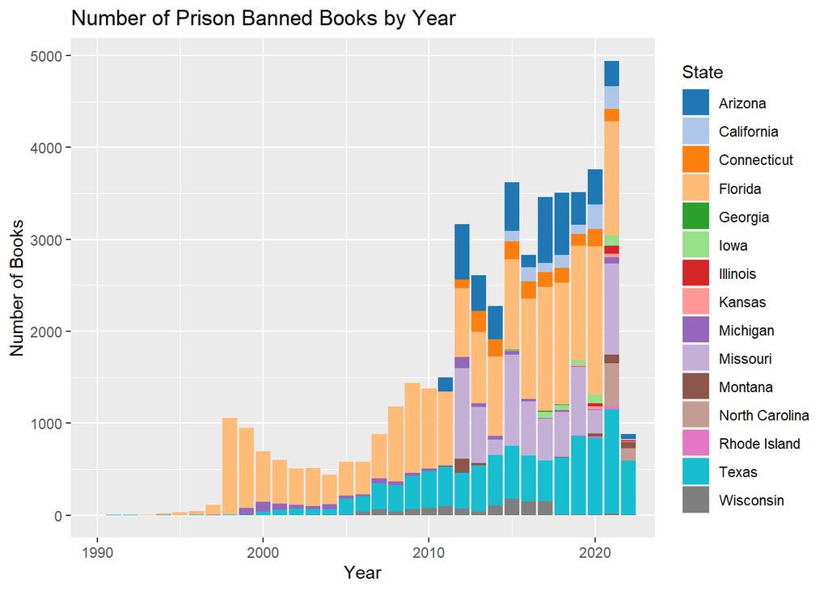

*Wordcloud of Book Titles*

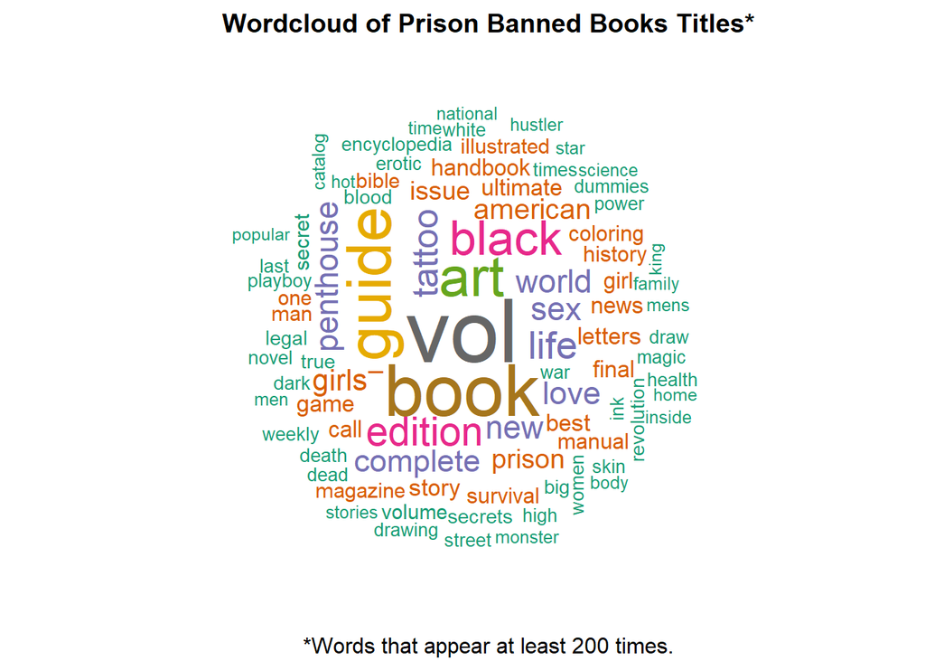

*Top 10 Banned Titles*

| Title | State Where Title Appeared | Count |
| --- | --- | --- |
| PLAYBOY | Florida | 155 |
| PENTHOUSE | Florida | 131 |
| MAXIM | Florida | 107 |
| TATTOO | Florida | 105 |
| HEAVY METAL | Florida | 101 |
| PENTHOUSE LETTERS | Florida | 100 |
| FOX | Florida | 85 |
| HUSTLER | Florida | 79 |
| GUIDE, THE | Florida | 77 |
| PLAYERS GIRLS PICTORIAL | Florida | 70 |

*Map of States that Provide a Reason for Banning Books and % of Books that have a Reason*

[interactive chart not shown]

*Wordcloud of Banning Reasons*

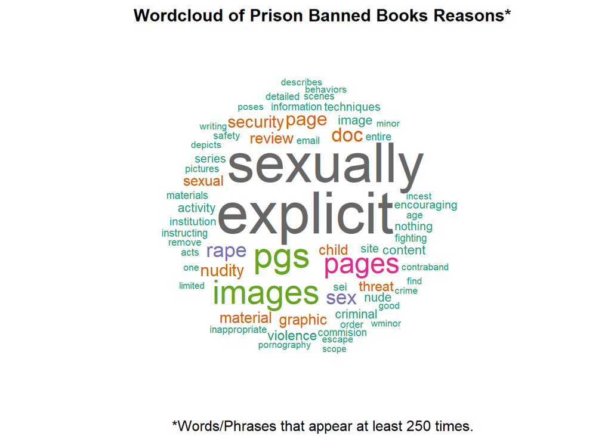